# Genralization analysis in deforestation and forest samples in Amazon Forest

# Introduction

The Amazon forest is the largest rainforest in the world, and it has a vital role in the carbon cycle and climate regulation. The majority of the Amazon forest is in Brazil, about 60%. Since the end of 80 decade, the Brazilian government has maintained projects based on remote sensing images to monitor the region. PRODES, launched in 1988, is a project with global respect, and it was responsible for a considerable decrease in the deforestation rate in the 90s and the beginning of the 2000s. However, deforestation has increased over the past 15 years, which concerns the Brazilian government.

Even with the evolution of machine learning methods, the visual analysis of the images is the primary method in PRODES and other monitoring projects. For some reason, the region is covered by clouds almost all year, which can result in noise samples and a low number of images with soil information. Another reason is the variability of the samples observed in the region. The Amazon forest has a distinct response over a year and more; the forest may be different depending on the location, and this can result in multiple patterns. Also, deforestation only occurs occasionally, presenting distinct patterns to samples. So, a machine learning method to produce information can be complex.

Considering the sampling process in machine learning methods, understanding how samples behave spatial and temporal is fundamental to improving the results of machine learning methods. Therefore, this work aims to produce a statistical analysis of samples of deforestation and forest in the Amazon forest to understand how much the patterns are different in the deforest and forest classes. Also, we analyze different samples in space and time to verify how much is possible generalize a clustering method.

# Hypotheses

General

- Can use short time series to improve the generalization of model?
- Is there a relationship between samples in different region and time?
- Is it possible generate a generic clustering algorithm considering time and space variation?

Spatial

- Samples in different tile can be classify using an single tile as reference.
- The patterns are similar in different tiles.
- Is possible produce a ML model generic as possible to classify different region?

Temporal

- Samples in a specific time step can be used to classify samples in the future
- The seasonal behavior of time series happen in the next years

# Lybraries used

```r
library(cluster)
library(sits)
library(sitsdata)
library(dplyr)
library(factoextra)
library(data.table)
library(sf)
library(dtwclust)
source("../src/sampling_sits.R")
```

# Region of interest

Study area The selected study area cover three Brazil states: ‘Rondonia’, ‘Amazonas’ e ‘Mato Grosso’. The major area is in the Rondonia State. Rondonia presented the fourth state with the most areas of deforestation in 2022, with 1480 km2. Also, the state has had the third-largest accumulated deforestation area (66103 km2) since 1988 (PRODES launch year). It makes the region a focus of attention for government authorities concerned with deforestation. Therefore, the region is a hotspot for illegal actions. Below is presented a code showing the study area location.

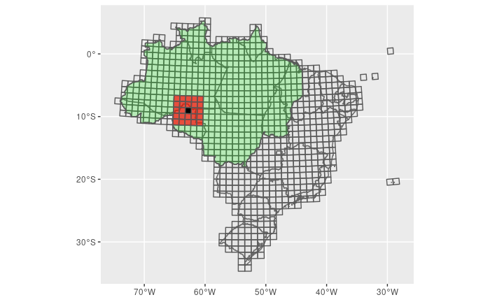

```r
federative_units <- sf::st_read("../../data/shp/uf_2020/uf_2020.shp")
roi <- sf::st_read("../../data/shp/roi_5x5/roi.shp")
brazilian_amazon <- sf::st_read("../../data/shp/brazilian_amazon/brazilian_legal_amazon.shp")
bdc_grid <- sf::st_read("../../data/shp/bdc_sm/bdc_sm_4326.shp")
ref_roi <- sf::st_read("../../data/shp/ref_roi/ref_roi.shp")
ggplot2::ggplot() +
  ggplot2::geom_sf(data = federative_units) +
  ggplot2::geom_sf(data = bdc_grid, alpha=1/10) +
  ggplot2::geom_sf(data = brazilian_amazon, fill = "green",alpha = 1/5) +
  ggplot2::geom_sf(data = roi, fill = "red",alpha = 1/1.5) +
  ggplot2::geom_sf(data = ref_roi, fill = "black")
```

**Legend**

- Green - Legal Amazon Forest
- Red - Study area
- Black - Reference tile - 013015 (train area)
- White - BDC grid
- Gray - Federative Units

# Data

The samples using a PRODES map to define their geographic location (longitude and latitude) and S2_SEN2COR_10_16D_STK-1 BDC cube provide the time series values. PRODES methodology allows us to define forest samples where it is possible to define a single class sample over two consecutive years safely. Considering deforestation areas, it is impossible to ensure a single class sample over these two years because the land cover can change along the selected period, e.g., pasture. However, it is possible to conclude that there was deforestation at the beginning of the time series period, and the ground truth is not a primary forest in all periods. The samples have 265026 time series: 182146 in forest and 82880 deforested areas. The R code above imports the samples and show the first six samples.

```r
samples <- readRDS("../../data/rds/samples/2018-2021/samples.rds")
head(samples)
```

| longitude | latitude | start_date | end_date | label | cube | time_series | tile |
| --- | --- | --- | --- | --- | --- | --- | --- |
| -62.28473 | -9.306880 | 2018-07-28 | 2021-07-12 | Forest | S2-16D-2 |  | 014015 |
| -62.27983 | -9.300420 | 2018-07-28 | 2021-07-12 | Forest | S2-16D-2 |  | 014015 |
| -62.27827 | -9.086901 | 2018-07-28 | 2021-07-12 | Forest | S2-16D-2 |  | 014015 |
| -62.27656 | -9.027976 | 2018-07-28 | 2021-07-12 | Forest | S2-16D-2 |  | 014015 |
| -62.27561 | -9.002932 | 2018-07-28 | 2021-07-12 | Forest | S2-16D-2 |  | 014015 |
| -62.27545 | -8.991605 | 2018-07-28 | 2021-07-12 | Forest | S2-16D-2 |  | 014015 |

# Statistical Analysis

Statistical analysis is a mathematical procedure to investigate trends, patterns and relationship through quantitative data. The method consists in collect data and summarize it using a descriptive statistics. To draw a valid conclusions using statistical analysis is important develop carefully the sampling procedure, use inferential statistics to test hypotheses, make estimates about the population to finally interpret and generalize your findings.

# General Analysis

The statistic analysis can allow us to understand the temporal and spatial behavior of the samples, showing patterns, trends, relationships, and variability using quantitative data. We will start presenting a summary of the bands’ values by class. The data comprises sentinel observations, including twelve bands and two vegetation indexes. The code above summarizes the time series data along the time by class. In this summary, we can visualize basic statistical measurements for each band by class.

- Forest samples

```r
forest_samples <- samples[samples$label == "Forest",]
ts <- forest_samples$time_series
dt <- dt <- data.table::data.table(dplyr::bind_rows(ts))
summary(dt)
```

```
     Index                 B01               B02               B03               B04
 Min.   :2018-07-28   Min.   :0.00010   Min.   :0.00010   Min.   :0.00010   Min.   :0.00010
 1st Qu.:2019-04-23   1st Qu.:0.02203   1st Qu.:0.02340   1st Qu.:0.03940   1st Qu.:0.02160
 Median :2020-01-17   Median :0.03340   Median :0.03295   Median :0.04977   Median :0.02920
 Mean   :2020-01-18   Mean   :0.04685   Mean   :0.04408   Mean   :0.05880   Mean   :0.03969
 3rd Qu.:2020-10-15   3rd Qu.:0.05360   3rd Qu.:0.04925   3rd Qu.:0.06487   3rd Qu.:0.04260
 Max.   :2021-07-12   Max.   :1.00000   Max.   :0.99980   Max.   :0.99960   Max.   :0.99910
      B05               B06              B07              B08              B8A              B09
 Min.   :0.00010   Min.   :0.0201   Min.   :0.0289   Min.   :0.0001   Min.   :0.0279   Min.   :0.0001
 1st Qu.:0.06550   1st Qu.:0.2033   1st Qu.:0.2611   1st Qu.:0.2593   1st Qu.:0.2925   1st Qu.:0.2931
 Median :0.07800   Median :0.2295   Median :0.2936   Median :0.2949   Median :0.3275   Median :0.3241
 Mean   :0.08588   Mean   :0.2329   Mean   :0.2965   Mean   :0.2951   Mean   :0.3294   Mean   :0.3347
 3rd Qu.:0.09500   3rd Qu.:0.2614   3rd Qu.:0.3316   3rd Qu.:0.3327   3rd Qu.:0.3677   3rd Qu.:0.3665
 Max.   :1.00000   Max.   :0.9989   Max.   :1.0000   Max.   :0.9996   Max.   :0.9977   Max.   :1.0000
      B11              B12               NDVI              EVI
 Min.   :0.0024   Min.   :0.00150   Min.   :-0.3847   Min.   :-0.9952
 1st Qu.:0.1404   1st Qu.:0.05780   1st Qu.: 0.7724   1st Qu.: 0.5288
 Median :0.1591   Median :0.06780   Median : 0.8373   Median : 0.5827
 Mean   :0.1636   Mean   :0.07729   Mean   : 0.7974   Mean   : 0.5816
 3rd Qu.:0.1837   3rd Qu.:0.08390   3rd Qu.: 0.8701   3rd Qu.: 0.6410
 Max.   :0.8366   Max.   :0.75820   Max.   : 0.9995   Max.   : 1.0000
```

- Deforestation samples

```r
deforestation_samples <- samples[samples$label == "Deforestation",]
ts <- deforestation_samples$time_series
dt <- dt <- data.table::data.table(dplyr::bind_rows(ts))
summary(dt)
```

```
     Index                 B01               B02               B03               B04
 Min.   :2018-07-28   Min.   :0.00010   Min.   :0.00010   Min.   :0.00170   Min.   :0.00060
 1st Qu.:2019-04-23   1st Qu.:0.03330   1st Qu.:0.04030   1st Qu.:0.06520   1st Qu.:0.04845
 Median :2020-01-17   Median :0.04740   Median :0.05320   Median :0.07780   Median :0.06690
 Mean   :2020-01-18   Mean   :0.05981   Mean   :0.06275   Mean   :0.08563   Mean   :0.07476
 3rd Qu.:2020-10-15   3rd Qu.:0.07000   3rd Qu.:0.07320   3rd Qu.:0.09665   3rd Qu.:0.09230
 Max.   :2021-07-12   Max.   :0.99970   Max.   :0.99780   Max.   :0.99600   Max.   :0.99820
      B05              B06              B07              B08              B8A              B09
 Min.   :0.0037   Min.   :0.0001   Min.   :0.0003   Min.   :0.0001   Min.   :0.0001   Min.   :0.0001
 1st Qu.:0.1042   1st Qu.:0.2067   1st Qu.:0.2421   1st Qu.:0.2411   1st Qu.:0.2710   1st Qu.:0.2746
 Median :0.1215   Median :0.2507   Median :0.2964   Median :0.2936   Median :0.3258   Median :0.3271
 Mean   :0.1274   Mean   :0.2514   Mean   :0.2980   Mean   :0.2930   Mean   :0.3258   Mean   :0.3318
 3rd Qu.:0.1444   3rd Qu.:0.2974   3rd Qu.:0.3549   3rd Qu.:0.3479   3rd Qu.:0.3839   3rd Qu.:0.3860
 Max.   :0.9980   Max.   :0.9982   Max.   :0.9917   Max.   :0.9994   Max.   :0.9985   Max.   :1.0000
      B11              B12              NDVI              EVI
 Min.   :0.0040   Min.   :0.0018   Min.   :-0.9661   Min.   :-0.9824
 1st Qu.:0.2070   1st Qu.:0.1071   1st Qu.: 0.5071   1st Qu.: 0.3620
 Median :0.2385   Median :0.1369   Median : 0.6480   Median : 0.4856
 Mean   :0.2429   Mean   :0.1471   Mean   : 0.6187   Mean   : 0.4771
 3rd Qu.:0.2767   3rd Qu.:0.1801   3rd Qu.: 0.7524   3rd Qu.: 0.5956
 Max.   :0.9994   Max.   :0.9945   Max.   : 0.9902   Max.   : 1.0000
```

To all values, we can observe a distortion between the median/mean and the maximum and maximum value measured for both the deforestation and the forest class. In this summary, the measures consider all values independent of the date, so we do not consider the temporal characteristic of the samples. These distortions can indicate that the observed value can not correspond to the actual land cover value at some point in the period. Some reasons for this can be the presence of clouds, aerosol interference, or pixel saturation. The interquartile range shows slight variation, indicating that most observed values have a singular pattern.

# Variation band

Above is presented a box plot for each band.

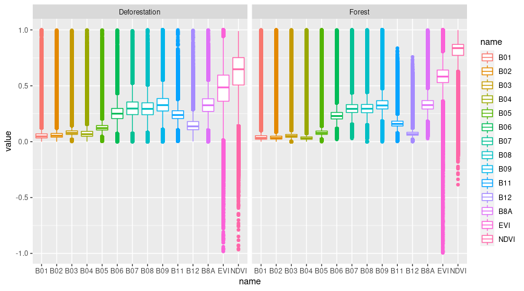

```r
plot_box(samples)
```

The interquartile variation is generally more significant for the Deforestation class than the Forest class, showing that the forest class presented a more homogeneous behavior. This behavior is expected considering the characteristics of the classes. The Amazon forest presents a massive tree concentration throughout the entire period. Meanwhile, deforestation is a non-homogeneous tree loss that can explain the variation, and the area can be another class, e.g., pasture. Still looking for the interquartile, the band variation is slight to all bands and slightly more significant to indexes. The bands B01 to B05 presented a slight variation considering the two classes. Contrasting Forest against Deforestation class, the band B12 to Forest class also presents a slight variation; meanwhile, the band B12 to Deforestation class presents more variation in comparison. The bands B06 to B11 present more variation in contrast to other bands. The indexes’ variation is more considerable, mainly considering the deforestation class. The median for the bands presents less variation to the classes compared to indexes; this shows how these indexes highlight the vegetation. All bands presented many numbers of outliers. To analyze these behaviors, we will explore the temporal characteristics to verify if these observations can be retired or if these outliers represent a natural variation considering clouds, for example.

Now, we are analyzing the behavior of the bands, considering the time variation. To simplify the visualization of the charts, we analyzed the two indexes (NDVI and EVI). Above, we plot two charts of the median and the quartiles. The command above calculated some statistics from the sample data: Mean, Median, Quartil 25%, Quartil 75%, Median, Standard deviation, and Correlation.

```r
stats <- stats_ts(samples)
```

- NDVI and EVI (Plotting Median and Quartils)

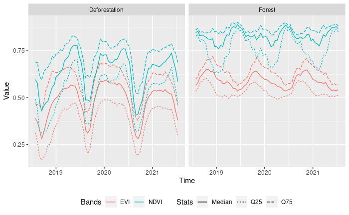

```r
plot_stats(stats, c("Median", "Q25", "Q75"), c("NDVI", "EVI"))
```

# Pattern analysis

In time series analysis, it is helpful to visualize the temporal patterns to understand the band variability over the period. The chart above presents a statistical approximation of the samples in a single plot with all available sentinel bands and two vegetation indexes. The patterns represent an additive model (GAM) to obtain a possible predictor.

The following code presents the function sits_patterns(). It uses the dtwSat R package to generate the patterns used in the plot.

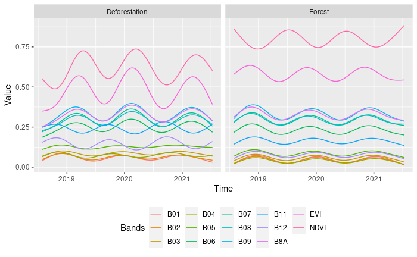

```r
patterns <- sits::sits_patterns(samples)
plot_patterns(patterns)
```

# Intra-class band Correlation

The previous patterns are sound indicative of the class’s behavior. Thus, their Correlation can support the previous analysis. The code below calculates the intra-class band correlation and plots it. Here, we desire to analyze numerically the relationship between the pattern bands of deforestation and Forest classes separately.

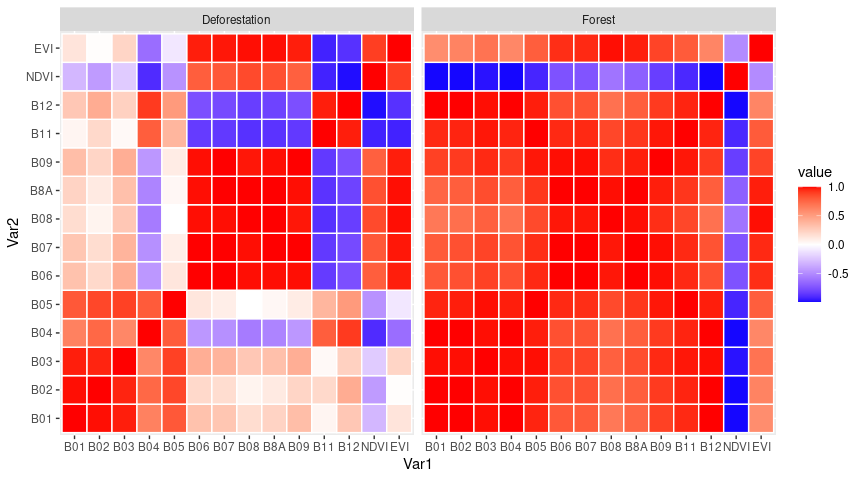

```r
cor <- corr_ts(patterns)
plot_corr_matrix(cor)
```

The intra-class Correlation of the band’s patterns to forest patterns reveals a high positive correlation to all bands except the NDVI band, which presents a negative correlation to other bands. We can separate four groups with a high positive correlation in the deforestation class: 1 (B01 to B05), 2 (B06 to B09), 3 (B11 to B12), and 4 (NDVI and EVI). Analyze the groups against each other: Group 1 practically has no Correlation to other groups; Group 2 presents a negative correlation to 3 and a positive correlation to 4; Group 3 presents a negative Correlation to 4. The previous analysis covers group 4 correlation against other groups.

# Inter-class band Correlation

The code below calculates the inter-class band correlation and plots it. Here, we want to analyze the band patterns correlation class against class, comparing the respective band of deforestation patterns with forest patterns.

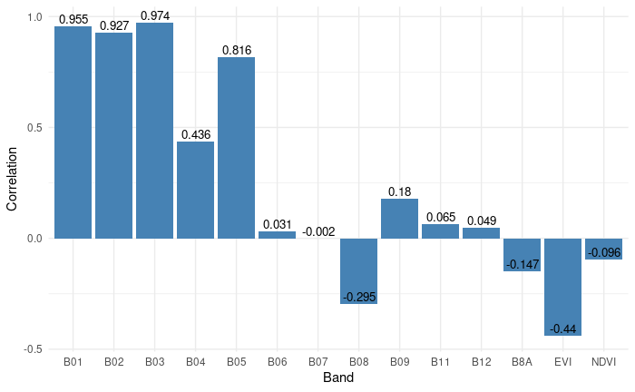

```r
df <- corr_classes(patterns)
ggplot2::ggplot(data=df, aes(x=Band, y=Correlation)) +
  ggplot2::geom_bar(stat="identity", fill="steelblue")+
  ggplot2::geom_text(aes(label=Correlation), vjust=-0.3, size=3.5)+
  ggplot2::theme_minimal()
```

# Bands Analysis

The previous intra-class Correlation analysis reveals that some band patterns are highly correlated. Indicating that some patterns have almost the same information, making it redundant to include them in an ML model. Including these highly correlated patterns in a model can lead to a multicollinearity problem. To avoid this problem, we developed a strategy to select features based on correlation analysis (Intra-class and Inter-class analysis). Based on the Intra-class correlation information to each class, we observed four groups with a high positive correlation considering the deforestation class. Through that information, we select the following bands by groups.

```r
bands <- c("B04", "B07","B12","NDVI", "EVI")
samples_013015 <- samples[samples$tile == "013015",]
samples_013015_1y <-subset_by_date (samples_013015, "2018-07-28","2019-07-12")
hclusters <- clusters_by_bands_combination(samples_013015_1y, bands, 5)
```

```
[1] "B04"
[1] "B07"
[1] "B12"
[1] "NDVI"
[1] "EVI"
[1] "B04" "B07"
[1] "B04" "B12"
[1] "B04"  "NDVI"
[1] "B04" "EVI"
[1] "B07" "B12"
[1] "B07"  "NDVI"
[1] "B07" "EVI"
[1] "B12"  "NDVI"
[1] "B12" "EVI"
[1] "NDVI" "EVI"
```

[output cut: 16 more lines]

The evaluation of the clustering uses distinct cluster and classification metrics to define the quality of each model. To calculate the classification metrics, we define a label for each cluster based on the majority, where the cluster label will be the class with more members in the cluster. Below is presented the evaluated metrics:

**Clustering indexes**

- RI: Rand Index.
- ARI: Adjusted Rand Index.
- J: Jaccard Index.
- FM: Fowlkes-Mallows
- VI: Soft Variation of Information
- Sil: Silhouette index
- D: Dunn index
- COP: COP index

**Classification metrics**

- ACC: Accuracy.
- ACC_F: Accuracy to Forest samples (Not used in voting).
- ACC_D: Accuracy to Forest samples (Not used in voting)..
- PREC: Precision.
- SENS: Sensitivity.
- SPEC: Specificity.
- F1: F1-Score.

In the code below, we calculate the metrics:

```r
metrics_score <- models_metrics(hclusters, samples_013015_1y)
```

```r
knitr::kable(metrics_score[1:11], caption="Best Models Pt1")
```

Best Models Pt1

| bands | Sil | D | COP | DB | DBstar | CH | SF | ARI | RI | J |
| --- | --- | --- | --- | --- | --- | --- | --- | --- | --- | --- |
| B04 | 0.5153368 | 0.0089402 | 9.937489 | 1.0456552 | 1.0456552 | 7803.615 | 0.4104379 | 0.9693962 | 0.9852949 | 0.9757384 |
| B07 | 0.4085699 | 0.0280334 | 3.511127 | 1.0850468 | 1.0850468 | 5080.755 | 0.2124009 | 0.4619333 | 0.7579759 | 0.6969020 |
| B12 | 0.6900985 | 0.0218444 | 6.371981 | 2.1323193 | 2.1323193 | 12464.551 | 0.3920684 | 0.9804356 | 0.9905975 | 0.9844127 |
| NDVI | 0.6208515 | 0.0195605 | 6.831853 | 1.7139549 | 1.7139549 | 10299.765 | 0.0814083 | 0.7196896 | 0.8690699 | 0.8125859 |
| EVI | 0.5509628 | 0.0240785 | 5.583342 | 1.0037535 | 1.0037535 | 7888.991 | 0.0644944 | 0.8369051 | 0.9225283 | 0.8810997 |
| B04/B07 | 0.3900739 | 0.0299661 | 4.308151 | 0.7023799 | 0.7023799 | 6112.096 | 0.0479973 | 0.9760354 | 0.9884730 | 0.9808911 |
| B04/B12 | 0.6120596 | 0.0282936 | 7.125032 | 1.4518743 | 1.4518743 | 10177.782 | 0.1827530 | 0.9853167 | 0.9929398 | 0.9882607 |
| B04/NDVI | 0.5780501 | 0.0152369 | 5.175003 | 1.1566726 | 1.1566726 | 9225.637 | 0.0277098 | 0.9720436 | 0.9865649 | 0.9778035 |
| B04/EVI | 0.5381375 | 0.0380874 | 6.370635 | 1.3395497 | 1.3395497 | 7983.233 | 0.0160750 | 0.7315874 | 0.8744389 | 0.8191100 |
| B07/B12 | 0.5180615 | 0.0343758 | 3.918852 | 0.9260901 | 0.9260901 | 6592.539 | 0.0385894 | 0.9800367 | 0.9903848 | 0.9839915 |
| B07/NDVI | 0.5047490 | 0.0428834 | 3.965067 | 1.0276271 | 1.0276271 | 8781.551 | 0.0038469 | 0.9862100 | 0.9933662 | 0.9889555 |
| B07/EVI | 0.5057352 | 0.0484561 | 5.445531 | 1.1821726 | 1.1821726 | 7378.690 | 0.0085774 | 0.7471102 | 0.8813453 | 0.8273046 |
| B12/NDVI | 0.5999667 | 0.0340777 | 4.227023 | 1.4407627 | 1.4407627 | 10616.256 | 0.0212932 | 0.9915378 | 0.9959289 | 0.9932065 |
| B12/EVI | 0.5806582 | 0.0555924 | 4.637421 | 1.5544589 | 1.5544589 | 7647.006 | 0.0110396 | 0.6619272 | 0.8433400 | 0.7827077 |
| NDVI/EVI | 0.5236113 | 0.0368024 | 4.130357 | 1.1303472 | 1.1303472 | 9885.147 | 0.0011989 | 0.9813324 | 0.9910229 | 0.9850938 |
| B04/B07/B12 | 0.5082322 | 0.0384003 | 4.501138 | 0.9944547 | 0.9944547 | 8160.844 | 0.0135969 | 0.9893195 | 0.9948603 | 0.9914262 |
| B04/B07/NDVI | 0.5010327 | 0.0353827 | 4.231078 | 0.9835521 | 0.9835521 | 8614.634 | 0.0014916 | 0.9839926 | 0.9923004 | 0.9871954 |
| B04/B07/EVI | 0.4618286 | 0.0448733 | 4.631543 | 0.7901952 | 0.7901952 | 6474.861 | 0.0016405 | 0.9799923 | 0.9903848 | 0.9840642 |
| B04/B12/NDVI | 0.5829102 | 0.0305551 | 4.788428 | 1.3356402 | 1.3356402 | 11348.218 | 0.0100507 | 0.9902059 | 0.9952876 | 0.9921387 |
| B04/B12/EVI | 0.5613957 | 0.0529812 | 5.401739 | 0.9956702 | 0.9956702 | 8333.838 | 0.0034233 | 0.7854557 | 0.8989833 | 0.8501299 |
| B04/NDVI/EVI | 0.5208535 | 0.0351369 | 4.443024 | 1.0291620 | 1.0291620 | 9153.707 | 0.0003772 | 0.9791092 | 0.9899597 | 0.9833627 |
| B07/B12/NDVI | 0.5339395 | 0.0542236 | 3.896423 | 1.0947574 | 1.0947574 | 9256.136 | 0.0010774 | 0.9888693 | 0.9946467 | 0.9910821 |
| B07/B12/EVI | 0.5113467 | 0.0470876 | 4.415311 | 1.0535734 | 1.0535734 | 7510.309 | 0.0014763 | 0.9866559 | 0.9935795 | 0.9893045 |
| B07/NDVI/EVI | 0.4984764 | 0.0466938 | 4.091403 | 0.9266460 | 0.9266460 | 8176.084 | 0.0000895 | 0.9786843 | 0.9897471 | 0.9829854 |
| B12/NDVI/EVI | 0.5706095 | 0.0560593 | 4.791841 | 1.5219747 | 1.5219747 | 8252.227 | 0.0001965 | 0.7155075 | 0.8672275 | 0.8104702 |
| B04/B07/B12/NDVI | 0.5283451 | 0.0487578 | 4.220126 | 1.0514389 | 1.0514389 | 8914.498 | 0.0004048 | 0.9893138 | 0.9948603 | 0.9914357 |
| B04/B07/B12/EVI | 0.5028089 | 0.0430619 | 4.453221 | 0.8911125 | 0.8911125 | 7170.114 | 0.0003646 | 0.9857727 | 0.9931530 | 0.9885926 |
| B04/B07/NDVI/EVI | 0.4967788 | 0.0367973 | 4.349112 | 0.9078634 | 0.9078634 | 8363.973 | 0.0000325 | 0.9853178 | 0.9929398 | 0.9882589 |
| B04/B12/NDVI/EVI | 0.5372850 | 0.0400809 | 4.425561 | 1.0560706 | 1.0560706 | 9077.386 | 0.0000864 | 0.9910916 | 0.9957151 | 0.9928538 |
| B07/B12/NDVI/EVI | 0.5191838 | 0.0496831 | 4.069701 | 0.9789756 | 0.9789756 | 8898.012 | 0.0000245 | 0.9879832 | 0.9942197 | 0.9903711 |
| B04/B07/B12/NDVI/EVI | 0.5159771 | 0.0532867 | 4.241347 | 0.9589308 | 0.9589308 | 8775.356 | 0.0000083 | 0.9902037 | 0.9952876 | 0.9921424 |

```r
knitr::kable(cbind(metrics_score[1],metrics_score[11:20]), caption="Best Models Pt2")
```

Best Models Pt2

| bands | J | FM | VI | ACC | PREC | SENS | F1 | SPEC | ACC_F | ACC_D |
| --- | --- | --- | --- | --- | --- | --- | --- | --- | --- | --- |
| B04 | 0.9757384 | 0.9877225 | 27.209525 | 0.9925934 | 0.9928805 | 0.9968727 | 0.9948726 | 0.9815456 | 0.9928805 | 0.9918415 |
| B07 | 0.6969020 | 0.8271722 | 3.886803 | 0.8591670 | 0.8376453 | 0.9980640 | 0.9108453 | 0.5005767 | 0.8376453 | 0.9901141 |
| B12 | 0.9844127 | 0.9921466 | 39.878895 | 0.9952769 | 0.9951017 | 0.9983619 | 0.9967291 | 0.9873126 | 0.9951017 | 0.9957348 |
| NDVI | 0.8125859 | 0.8980314 | 5.767082 | 0.9295835 | 0.9113374 | 0.9995532 | 0.9534091 | 0.7489427 | 0.9113374 | 0.9984623 |
| EVI | 0.8810997 | 0.9370869 | 7.706863 | 0.9596393 | 0.9516888 | 0.9944899 | 0.9726187 | 0.8696655 | 0.9516888 | 0.9839060 |
| B04/B07 | 0.9808911 | 0.9903534 | 32.892551 | 0.9942035 | 0.9959792 | 0.9959792 | 0.9959792 | 0.9896194 | 0.9959792 | 0.9896194 |
| B04/B12 | 0.9882607 | 0.9940960 | 50.046129 | 0.9964577 | 0.9968769 | 0.9982130 | 0.9975445 | 0.9919262 | 0.9968769 | 0.9953704 |
| B04/NDVI | 0.9778035 | 0.9887788 | 29.278620 | 0.9932374 | 0.9936183 | 0.9970216 | 0.9953170 | 0.9834679 | 0.9936183 | 0.9922420 |
| B04/EVI | 0.8191100 | 0.9018611 | 5.931957 | 0.9326964 | 0.9149400 | 0.9995532 | 0.9553768 | 0.7600923 | 0.9149400 | 0.9984848 |
| B07/B12 | 0.9839915 | 0.9919349 | 40.528308 | 0.9951696 | 0.9992515 | 0.9940432 | 0.9966405 | 0.9980777 | 0.9992515 | 0.9848255 |
| B07/NDVI | 0.9889555 | 0.9944471 | 52.497303 | 0.9966724 | 0.9979142 | 0.9974684 | 0.9976912 | 0.9946175 | 0.9979142 | 0.9934716 |
| B07/EVI | 0.8273046 | 0.9065472 | 6.003814 | 0.9366681 | 0.9208465 | 0.9979151 | 0.9578330 | 0.7785467 | 0.9208465 | 0.9931339 |
| B12/NDVI | 0.9932065 | 0.9965917 | 80.062981 | 0.9979605 | 0.9989568 | 0.9982130 | 0.9985847 | 0.9973087 | 0.9989568 | 0.9953952 |
| B12/EVI | 0.7827077 | 0.8802883 | 5.172696 | 0.9143409 | 0.8937841 | 1.0000000 | 0.9439134 | 0.6931949 | 0.8937841 | 1.0000000 |
| NDVI/EVI | 0.9850938 | 0.9924911 | 40.663583 | 0.9954916 | 0.9964291 | 0.9973194 | 0.9968741 | 0.9907728 | 0.9964291 | 0.9930636 |
| B04/B07/B12 | 0.9914262 | 0.9956951 | 66.485558 | 0.9974238 | 0.9991049 | 0.9973194 | 0.9982114 | 0.9976932 | 0.9991049 | 0.9931114 |
| B04/B07/NDVI | 0.9871954 | 0.9935564 | 46.225659 | 0.9961357 | 0.9973194 | 0.9973194 | 0.9973194 | 0.9930796 | 0.9973194 | 0.9930796 |
| B04/B07/EVI | 0.9840642 | 0.9919698 | 39.176870 | 0.9951696 | 0.9949540 | 0.9983619 | 0.9966550 | 0.9869281 | 0.9949540 | 0.9957331 |
| B04/B12/NDVI | 0.9921387 | 0.9960540 | 70.947910 | 0.9976385 | 0.9989563 | 0.9977662 | 0.9983609 | 0.9973087 | 0.9989563 | 0.9942507 |
| B04/B12/EVI | 0.8501299 | 0.9197982 | 6.888866 | 0.9466509 | 0.9314460 | 0.9995532 | 0.9642985 | 0.8100730 | 0.9314460 | 0.9985782 |
| B04/NDVI/EVI | 0.9833627 | 0.9916130 | 37.572136 | 0.9949549 | 0.9949525 | 0.9980640 | 0.9965058 | 0.9869281 | 0.9949525 | 0.9949612 |
| B07/B12/NDVI | 0.9910821 | 0.9955211 | 63.062020 | 0.9973164 | 0.9979160 | 0.9983619 | 0.9981389 | 0.9946175 | 0.9979160 | 0.9957660 |
| B07/B12/EVI | 0.9893045 | 0.9946237 | 54.230961 | 0.9967797 | 0.9983599 | 0.9971705 | 0.9977649 | 0.9957709 | 0.9983599 | 0.9927175 |
| B07/NDVI/EVI | 0.9829854 | 0.9914197 | 36.293771 | 0.9948476 | 0.9964259 | 0.9964259 | 0.9964259 | 0.9907728 | 0.9964259 | 0.9907728 |
| B12/NDVI/EVI | 0.8104702 | 0.8968165 | 5.771534 | 0.9285101 | 0.9097683 | 1.0000000 | 0.9527526 | 0.7439446 | 0.9097683 | 1.0000000 |
| B04/B07/B12/NDVI | 0.9914357 | 0.9956994 | 65.261033 | 0.9974238 | 0.9980646 | 0.9983619 | 0.9982132 | 0.9950019 | 0.9980646 | 0.9957676 |
| B04/B07/B12/EVI | 0.9885926 | 0.9942642 | 51.840848 | 0.9965650 | 0.9986569 | 0.9965748 | 0.9976148 | 0.9965398 | 0.9986569 | 0.9912046 |
| B04/B07/NDVI/EVI | 0.9882589 | 0.9940949 | 49.930421 | 0.9964577 | 0.9970247 | 0.9980640 | 0.9975441 | 0.9923106 | 0.9970247 | 0.9949884 |
| B04/B12/NDVI/EVI | 0.9928538 | 0.9964141 | 76.240472 | 0.9978532 | 0.9985108 | 0.9985108 | 0.9985108 | 0.9961553 | 0.9985108 | 0.9961553 |
| B07/B12/NDVI/EVI | 0.9903711 | 0.9951623 | 59.000866 | 0.9971018 | 0.9980637 | 0.9979151 | 0.9979894 | 0.9950019 | 0.9980637 | 0.9946195 |
| B04/B07/B12/NDVI/EVI | 0.9921424 | 0.9960557 | 70.303527 | 0.9976385 | 0.9985104 | 0.9982130 | 0.9983616 | 0.9961553 | 0.9985104 | 0.9953899 |

To select the best model based on the configuration bands, a voting schema using the clustering and classification metrics. Where each metric contributes with one single vote, the vote of the model depends on how the metric works. In some metrics, the target is to select the maximum between all band combinations by the given values; in others, the objective is to select the minimum value. In the minimum case, invert the metric value and select the maximum value measured. In the code below, we voted the best model, considering the number of bands.

```r
best <- metrics_score[voting_best(metrics_score),]
best_clusters <- list()
best_clusters <- append(best_clusters, list(hclusters[[voting_best(metrics_score)]]))
```

```r
to_show <- cbind(best[1],best[14])
to_show <- cbind(to_show,best[19])
to_show <- cbind(to_show,best[20])
knitr::kable(to_show, caption="Best Model")
```

Best Model

|  | bands | ACC | ACC_F | ACC_D |
| --- | --- | --- | --- | --- |
| 13 | B12/NDVI | 0.9979605 | 0.9989568 | 0.9953952 |

The code below selects the best clustering for each band combination. The code makes a voting schema to select the best model among the models with one, two (not done is the best configuration selected above), three, four, and five bands. At the end of the code, all the best models were recovered from the list `hclusters` and put in another list called `best` .

```r
best <- rbind(best, metrics_score[voting_nbands(metrics_score,1),])
best <-rbind(best, metrics_score[voting_nbands(metrics_score,3),])
best <-rbind(best, metrics_score[voting_nbands(metrics_score,4),])
best <-rbind(best, metrics_score[voting_nbands(metrics_score,5),])
best_clusters <- append(best_clusters, list(
  hclusters[[voting_nbands(metrics_score,1)]]))
best_clusters <- append(best_clusters, list(
  hclusters[[voting_nbands(metrics_score,3)]]))
best_clusters <- append(best_clusters, list(
  hclusters[[voting_nbands(metrics_score,4)]]))
best_clusters <- append(best_clusters, list(
  hclusters[[voting_nbands(metrics_score,5)]]))
```

```r
to_show <- cbind(best[1],best[14:20])
knitr::kable(to_show, caption="Best Models")
```

Best Models

|  | bands | ACC | PREC | SENS | F1 | SPEC | ACC_F | ACC_D |
| --- | --- | --- | --- | --- | --- | --- | --- | --- |
| 13 | B12/NDVI | 0.9979605 | 0.9989568 | 0.9982130 | 0.9985847 | 0.9973087 | 0.9989568 | 0.9953952 |
| 3 | B12 | 0.9952769 | 0.9951017 | 0.9983619 | 0.9967291 | 0.9873126 | 0.9951017 | 0.9957348 |
| 19 | B04/B12/NDVI | 0.9976385 | 0.9989563 | 0.9977662 | 0.9983609 | 0.9973087 | 0.9989563 | 0.9942507 |
| 29 | B04/B12/NDVI/EVI | 0.9978532 | 0.9985108 | 0.9985108 | 0.9985108 | 0.9961553 | 0.9985108 | 0.9961553 |
| 31 | B04/B07/B12/NDVI/EVI | 0.9976385 | 0.9985104 | 0.9982130 | 0.9983616 | 0.9961553 | 0.9985104 | 0.9953899 |

# Generalization Test

- **BDC TILES**

```r
print("BDC TILES")
```

```
[1] "BDC TILES"
```

```r
unique(samples$tile)
```

```
 [1] "014015" "014016" "012014" "012015" "012016" "013014" "013015" "013016" "014014"
[10] "011013" "011014" "015013" "015015" "011015" "011017" "012017" "013017" "014017"
[19] "012013" "013013" "014013" "015014" "015016" "011016" "015017"
```

- **Time Series time steps**

```r
samples$time_series[[1]]$Index
```

```
 [1] "2018-07-28" "2018-08-13" "2018-08-29" "2018-09-14" "2018-09-30" "2018-10-16"
 [7] "2018-11-01" "2018-11-17" "2018-12-03" "2018-12-19" "2019-01-01" "2019-01-17"
[13] "2019-02-02" "2019-02-18" "2019-03-06" "2019-03-22" "2019-04-07" "2019-04-23"
[19] "2019-05-09" "2019-05-25" "2019-06-10" "2019-06-26" "2019-07-12" "2019-07-28"
[25] "2019-08-13" "2019-08-29" "2019-09-14" "2019-09-30" "2019-10-16" "2019-11-01"
[31] "2019-11-17" "2019-12-03" "2019-12-19" "2020-01-01" "2020-01-17" "2020-02-02"
[37] "2020-02-18" "2020-03-05" "2020-03-21" "2020-04-06" "2020-04-22" "2020-05-08"
[43] "2020-05-24" "2020-06-09" "2020-06-25" "2020-07-11" "2020-07-27" "2020-08-12"
[49] "2020-08-28" "2020-09-13" "2020-09-29" "2020-10-15" "2020-10-31" "2020-11-16"
[55] "2020-12-02" "2020-12-18" "2021-01-01" "2021-01-17" "2021-02-02" "2021-02-18"
[61] "2021-03-06" "2021-03-22" "2021-04-07" "2021-04-23" "2021-05-09" "2021-05-25"
[67] "2021-06-10" "2021-06-26" "2021-07-12"
```

In the section Bands Analysis, the training dataset (`samples_013015_1y`) used to generate the models comprises samples from the center tile (013015) of the study area. Also, the train samples comprehend the period 2018-07-28 to 2019-07-12, the first year of the original samples.

The generalization analysis uses distinct areas and periods, generating a robust test set. The space generalization analysis uses samples at other tiles with the same period. The time generalization test uses a time series with distinct periods, more precisely, the next two years of original samples.

## Space generalization test

In this test, we want to verify how the models perform in other tiles and if the models perform well in the generalization test. Below are presented classification metrics to evaluate the performance of the models. The `prediction_test` function also save the predictions of each model into a csv file.

```r
train_test_eval <- list()
for(i in 1:length(best_clusters)){
  pred <- prediction_test(samples,
                  best_clusters[[i]],
                  "2018-07-28",
                  "2019-07-12",
                  "../../data/csv/predicted/B04-B07-B12-NDVI-EVI",
                  "013015")
  train_test_eval <- append(train_test_eval, list(pred))
}
```

```r
to_show <- bind_rows(train_test_eval)
knitr::kable(to_show[3:11], caption="Spatial Generalization (Train Test)")
```

Spatial Generalization (Train Test)

| bands | type | ACC | PREC | SENS | F1 | SPEC | ACC_F | ACC_D |
| --- | --- | --- | --- | --- | --- | --- | --- | --- |
| B12-NDVI | Train | 0.9787455 | 0.9707541 | 0.9991765 | 0.9847602 | 0.9338441 | 0.9707541 | 0.9980657 |
| B12-NDVI | Generalization(Test) | 0.9784600 | 0.9703126 | 0.9991735 | 0.9845316 | 0.9331955 | 0.9703126 | 0.9980682 |
| B12 | Train | 0.9881936 | 0.9857333 | 0.9972549 | 0.9914606 | 0.9682794 | 0.9857333 | 0.9938081 |
| B12 | Generalization(Test) | 0.9879942 | 0.9854665 | 0.9972069 | 0.9913019 | 0.9678621 | 0.9854665 | 0.9937331 |
| B04-B12-NDVI | Train | 0.9763269 | 0.9672824 | 0.9993577 | 0.9830584 | 0.9257119 | 0.9672824 | 0.9984774 |
| B04-B12-NDVI | Generalization(Test) | 0.9759845 | 0.9667597 | 0.9993559 | 0.9827876 | 0.9249119 | 0.9667597 | 0.9984804 |
| B04-B12-NDVI-EVI | Train | 0.9651808 | 0.9524375 | 0.9992369 | 0.9752761 | 0.8903354 | 0.9524375 | 0.9981198 |
| B04-B12-NDVI-EVI | Generalization(Test) | 0.9649838 | 0.9521006 | 0.9992305 | 0.9750964 | 0.8901456 | 0.9521006 | 0.9981144 |
| B04-B07-B12-NDVI-EVI | Train | 0.9614038 | 0.9476422 | 0.9990392 | 0.9726622 | 0.8786921 | 0.9476422 | 0.9976028 |
| B04-B07-B12-NDVI-EVI | Generalization(Test) | 0.9611239 | 0.9471978 | 0.9990253 | 0.9724214 | 0.8782994 | 0.9471978 | 0.9975806 |

- Best Model in Spatial Generalization

```r
one_df <- bind_rows(train_test_eval)
only_test <- one_df[one_df$type == "Generalization(Test)",]
spatial_gen_best <- only_test[voting_best(only_test),]
spatial_gen_best[1:5]
```

|  | start_date | end_date | bands | type | ACC |
| --- | --- | --- | --- | --- | --- |
| 4 | 2018-07-28 | 2019-07-12 | B12 | Generalization(Test) | 0.9879942 |

- Best Model in Spatial Generalization by Tile

```r
path <- "../../data/csv/predicted/B04-B07-B12-NDVI-EVI"
band <- spatial_gen_best$bands
start_date <- spatial_gen_best$start_date
end_date <- spatial_gen_best$end_date
file <- paste("cluster", band, sep = "_")
file <- paste(file, start_date, sep = "-")
file <- paste(file, end_date, sep = "-")
file <- paste(file, "csv", sep = ".")
file <- paste(path, file, sep = "/")
best_gen_predictions <- read.csv(file)
knitr::kable(head(best_gen_predictions), caption="Best Model Predictions (Train Test)")
```

Best Model Predictions (Train Test)

| X | latitude | longitude | start_date | end_date | label | cube | tile | cluster_prediction | cluster_labeled |
| --- | --- | --- | --- | --- | --- | --- | --- | --- | --- |
| 1 | -9.306880 | -62.28473 | 2018-07-28 | 2019-07-12 | Forest | S2-16D-2 | 14015 | 1 | Forest |
| 2 | -9.300420 | -62.27983 | 2018-07-28 | 2019-07-12 | Forest | S2-16D-2 | 14015 | 1 | Forest |
| 3 | -9.086901 | -62.27827 | 2018-07-28 | 2019-07-12 | Forest | S2-16D-2 | 14015 | 1 | Forest |
| 4 | -9.027976 | -62.27656 | 2018-07-28 | 2019-07-12 | Forest | S2-16D-2 | 14015 | 1 | Forest |
| 5 | -9.002932 | -62.27561 | 2018-07-28 | 2019-07-12 | Forest | S2-16D-2 | 14015 | 1 | Forest |
| 6 | -8.991605 | -62.27545 | 2018-07-28 | 2019-07-12 | Forest | S2-16D-2 | 14015 | 1 | Forest |

```r
metric_by_tile <- prediction_metrics_by_tile(
  best_gen_predictions,
  start_date,
  end_date,
  band)
metric_by_tile <- metric_by_tile[order(-metric_by_tile$ACC),]
knitr::kable(metric_by_tile, caption="Metrics by Tile (model B12)")
```

Metrics by Tile (model B12)

|  | tile | start_date | end_date | band | ACC | PREC | SENS | F1 | SPEC | ACC_F | ACC_D |
| --- | --- | --- | --- | --- | --- | --- | --- | --- | --- | --- | --- |
| 22 | 15014 | 2018-07-28 | 2019-07-12 | B12 | 0.9994456 | 0.9991430 | 1.0000000 | 0.9995713 | 0.9984323 | 0.9991430 | 1.0000000 |
| 19 | 12013 | 2018-07-28 | 2019-07-12 | B12 | 0.9988818 | 0.9989066 | 0.9996874 | 0.9992968 | 0.9957627 | 0.9989066 | 0.9987857 |
| 12 | 15013 | 2018-07-28 | 2019-07-12 | B12 | 0.9969301 | 0.9963208 | 0.9997047 | 0.9980099 | 0.9876421 | 0.9963208 | 0.9990000 |
| 10 | 11013 | 2018-07-28 | 2019-07-12 | B12 | 0.9957379 | 0.9957704 | 0.9980620 | 0.9969149 | 0.9905660 | 0.9957704 | 0.9956651 |
| 9 | 14014 | 2018-07-28 | 2019-07-12 | B12 | 0.9955547 | 0.9951543 | 0.9989759 | 0.9970615 | 0.9850158 | 0.9951543 | 0.9968077 |
| 25 | 15017 | 2018-07-28 | 2019-07-12 | B12 | 0.9952901 | 0.9937456 | 0.9981036 | 0.9959198 | 0.9914695 | 0.9937456 | 0.9974093 |
| 11 | 11014 | 2018-07-28 | 2019-07-12 | B12 | 0.9949833 | 0.9950863 | 0.9997704 | 0.9974228 | 0.8346154 | 0.9950863 | 0.9908676 |
| 7 | 13015 | 2018-07-28 | 2019-07-12 | B12 | 0.9936668 | 0.9927450 | 0.9985108 | 0.9956196 | 0.9811611 | 0.9927450 | 0.9960968 |
| 16 | 12017 | 2018-07-28 | 2019-07-12 | B12 | 0.9928840 | 0.9911257 | 0.9982858 | 0.9946929 | 0.9820153 | 0.9911257 | 0.9965000 |
| 23 | 15016 | 2018-07-28 | 2019-07-12 | B12 | 0.9926405 | 0.9908639 | 0.9996500 | 0.9952375 | 0.9692727 | 0.9908639 | 0.9987976 |
| 17 | 13017 | 2018-07-28 | 2019-07-12 | B12 | 0.9917161 | 0.9887742 | 0.9983971 | 0.9935624 | 0.9798247 | 0.9887742 | 0.9970966 |
| 6 | 13014 | 2018-07-28 | 2019-07-12 | B12 | 0.9916605 | 0.9909413 | 0.9986769 | 0.9947941 | 0.9639687 | 0.9909413 | 0.9946121 |
| 20 | 13013 | 2018-07-28 | 2019-07-12 | B12 | 0.9902585 | 0.9881344 | 0.9981560 | 0.9931199 | 0.9714411 | 0.9881344 | 0.9954975 |
| 14 | 11015 | 2018-07-28 | 2019-07-12 | B12 | 0.9899360 | 0.9867819 | 0.9982001 | 0.9924581 | 0.9736509 | 0.9867819 | 0.9963702 |
| 4 | 12015 | 2018-07-28 | 2019-07-12 | B12 | 0.9897998 | 0.9911091 | 0.9927547 | 0.9919312 | 0.9847348 | 0.9911091 | 0.9875454 |
| 3 | 12014 | 2018-07-28 | 2019-07-12 | B12 | 0.9897579 | 0.9880250 | 0.9971064 | 0.9925449 | 0.9738682 | 0.9880250 | 0.9936162 |
| 8 | 13016 | 2018-07-28 | 2019-07-12 | B12 | 0.9887095 | 0.9890966 | 0.9927516 | 0.9909207 | 0.9820972 | 0.9890966 | 0.9880702 |
| 1 | 14015 | 2018-07-28 | 2019-07-12 | B12 | 0.9863095 | 0.9829456 | 0.9987377 | 0.9907787 | 0.9515870 | 0.9829456 | 0.9963075 |
| 18 | 14017 | 2018-07-28 | 2019-07-12 | B12 | 0.9824181 | 0.9800335 | 0.9927334 | 0.9863426 | 0.9641169 | 0.9800335 | 0.9868045 |
| 2 | 14016 | 2018-07-28 | 2019-07-12 | B12 | 0.9815657 | 0.9750324 | 0.9986731 | 0.9867112 | 0.9443131 | 0.9750324 | 0.9969495 |
| 21 | 14013 | 2018-07-28 | 2019-07-12 | B12 | 0.9791598 | 0.9679400 | 0.9996478 | 0.9835384 | 0.9453329 | 0.9679400 | 0.9993852 |
| 5 | 12016 | 2018-07-28 | 2019-07-12 | B12 | 0.9774197 | 0.9882132 | 0.9745620 | 0.9813401 | 0.9818755 | 0.9882132 | 0.9611725 |
| 15 | 11017 | 2018-07-28 | 2019-07-12 | B12 | 0.9732221 | 0.9608639 | 0.9994932 | 0.9797980 | 0.9244987 | 0.9608639 | 0.9989844 |
| 24 | 11016 | 2018-07-28 | 2019-07-12 | B12 | 0.9649625 | 0.9421741 | 0.9976201 | 0.9691047 | 0.9249138 | 0.9421741 | 0.9968544 |
| 13 | 15015 | 2018-07-28 | 2019-07-12 | B12 | 0.9648325 | 0.9546753 | 0.9981823 | 0.9759441 | 0.8813008 | 0.9546753 | 0.9948605 |

## Time generalization test

In this test we want verify how the models perform in other periods and verify if the models generalize. Below is presented classification metrics to evaluate the performance of the models.

### First Period 2019-07-28 to 2020-07-11

```r
time_generalization_2019_2020 <- list()
for(i in 1:length(best_clusters)){
  pred <- prediction_test(samples,
                  best_clusters[[i]],
                  "2019-07-28",
                  "2020-07-11",
                  "../../data/csv/predicted/B04-B07-B12-NDVI-EVI/2019-2020")
  time_generalization_2019_2020 <- append(time_generalization_2019_2020, list(pred))
}
```

```r
to_show <- bind_rows(time_generalization_2019_2020)
knitr::kable(to_show[3:11], caption="Time Generalization 2019-2020")
```

Time Generalization 2019-2020

| bands | type | ACC | PREC | SENS | F1 | SPEC | ACC_F | ACC_D |
| --- | --- | --- | --- | --- | --- | --- | --- | --- |
| B12-NDVI | Generalization(Test) | 0.9697728 | 0.9585613 | 0.9992149 | 0.9784660 | 0.9050676 | 0.9585613 | 0.9980973 |
| B12 | Generalization(Test) | 0.9846506 | 0.9807929 | 0.9971946 | 0.9889257 | 0.9570825 | 0.9807929 | 0.9935992 |
| B04-B12-NDVI | Generalization(Test) | 0.9666787 | 0.9542917 | 0.9993851 | 0.9763180 | 0.8947997 | 0.9542917 | 0.9984920 |
| B04-B12-NDVI-EVI | Generalization(Test) | 0.9499559 | 0.9329556 | 0.9989734 | 0.9648365 | 0.8422297 | 0.9329556 | 0.9973282 |
| B04-B07-B12-NDVI-EVI | Generalization(Test) | 0.9451110 | 0.9270669 | 0.9987043 | 0.9615532 | 0.8273287 | 0.9270669 | 0.9965700 |

```r
one_df <- bind_rows(time_generalization_2019_2020)
best <- one_df[voting_best(one_df),]
best[1:5]
```

|  | start_date | end_date | bands | type | ACC |
| --- | --- | --- | --- | --- | --- |
| 2 | 2019-07-28 | 2020-07-11 | B12 | Generalization(Test) | 0.9846506 |

```r
path <- "../../data/csv/predicted/B04-B07-B12-NDVI-EVI/2019-2020"
band <- best$bands
start_date <- best$start_date
end_date <- best$end_date
file <- paste("cluster", band, sep = "_")
file <- paste(file, start_date, sep = "-")
file <- paste(file, end_date, sep = "-")
file <- paste(file, "csv", sep = ".")
file <- paste(path, file, sep = "/")
best_predictions_2019_2020 <- read.csv(file)
knitr::kable(head(best_predictions_2019_2020),
             caption="Best Model Predictions (2019-2020)")
```

Best Model Predictions (2019-2020)

| X | latitude | longitude | start_date | end_date | label | cube | tile | cluster_prediction | cluster_labeled |
| --- | --- | --- | --- | --- | --- | --- | --- | --- | --- |
| 1 | -9.306880 | -62.28473 | 2019-07-28 | 2020-07-11 | Forest | S2-16D-2 | 14015 | 1 | Forest |
| 2 | -9.300420 | -62.27983 | 2019-07-28 | 2020-07-11 | Forest | S2-16D-2 | 14015 | 1 | Forest |
| 3 | -9.086901 | -62.27827 | 2019-07-28 | 2020-07-11 | Forest | S2-16D-2 | 14015 | 1 | Forest |
| 4 | -9.027976 | -62.27656 | 2019-07-28 | 2020-07-11 | Forest | S2-16D-2 | 14015 | 1 | Forest |
| 5 | -9.002932 | -62.27561 | 2019-07-28 | 2020-07-11 | Forest | S2-16D-2 | 14015 | 1 | Forest |
| 6 | -8.991605 | -62.27545 | 2019-07-28 | 2020-07-11 | Forest | S2-16D-2 | 14015 | 1 | Forest |

```r
metric_by_tile <- prediction_metrics_by_tile(
  best_predictions_2019_2020,
  start_date,
  end_date,
  band)
metric_by_tile <- metric_by_tile[order(-metric_by_tile$ACC),]
knitr::kable(metric_by_tile, caption="Metrics by Tile")
```

Metrics by Tile

|  | tile | start_date | end_date | band | ACC | PREC | SENS | F1 | SPEC | ACC_F | ACC_D |
| --- | --- | --- | --- | --- | --- | --- | --- | --- | --- | --- | --- |
| 16 | 12017 | 2019-07-28 | 2020-07-11 | B12 | 0.9982823 | 0.9988976 | 0.9985307 | 0.9987141 | 0.9977827 | 0.9988976 | 0.9970458 |
| 25 | 15017 | 2019-07-28 | 2020-07-11 | B12 | 0.9962457 | 0.9946884 | 0.9988147 | 0.9967473 | 0.9927571 | 0.9946884 | 0.9983814 |
| 6 | 13014 | 2019-07-28 | 2020-07-11 | B12 | 0.9936662 | 0.9930300 | 0.9990738 | 0.9960427 | 0.9723238 | 0.9930300 | 0.9962547 |
| 19 | 12013 | 2019-07-28 | 2020-07-11 | B12 | 0.9934153 | 0.9919355 | 0.9998437 | 0.9958739 | 0.9685230 | 0.9919355 | 0.9993754 |
| 4 | 12015 | 2019-07-28 | 2020-07-11 | B12 | 0.9932316 | 0.9962144 | 0.9930566 | 0.9946330 | 0.9935317 | 0.9962144 | 0.9881626 |
| 11 | 11014 | 2019-07-28 | 2020-07-11 | B12 | 0.9931996 | 0.9930453 | 1.0000000 | 0.9965105 | 0.7653846 | 0.9930453 | 1.0000000 |
| 18 | 14017 | 2019-07-28 | 2020-07-11 | B12 | 0.9927968 | 0.9961108 | 0.9926123 | 0.9943585 | 0.9931242 | 0.9961108 | 0.9869742 |
| 7 | 13015 | 2019-07-28 | 2020-07-11 | B12 | 0.9924860 | 0.9917123 | 0.9979151 | 0.9948040 | 0.9784698 | 0.9917123 | 0.9945291 |
| 8 | 13016 | 2019-07-28 | 2020-07-11 | B12 | 0.9923260 | 0.9968540 | 0.9907618 | 0.9937986 | 0.9948849 | 0.9968540 | 0.9850368 |
| 17 | 13017 | 2019-07-28 | 2020-07-11 | B12 | 0.9917895 | 0.9895526 | 0.9977101 | 0.9936146 | 0.9812513 | 0.9895526 | 0.9958635 |
| 1 | 14015 | 2019-07-28 | 2020-07-11 | B12 | 0.9916336 | 0.9909951 | 0.9977048 | 0.9943387 | 0.9746714 | 0.9909951 | 0.9934641 |
| 23 | 15016 | 2019-07-28 | 2020-07-11 | B12 | 0.9912942 | 0.9893740 | 0.9994166 | 0.9943700 | 0.9642163 | 0.9893740 | 0.9979871 |
| 15 | 11017 | 2019-07-28 | 2020-07-11 | B12 | 0.9907814 | 0.9863333 | 0.9996622 | 0.9929530 | 0.9743108 | 0.9863333 | 0.9993573 |
| 13 | 15015 | 2019-07-28 | 2020-07-11 | B12 | 0.9900714 | 0.9875465 | 0.9987016 | 0.9930928 | 0.9684553 | 0.9875465 | 0.9966533 |
| 3 | 12014 | 2019-07-28 | 2020-07-11 | B12 | 0.9851024 | 0.9810815 | 0.9974468 | 0.9891965 | 0.9584100 | 0.9810815 | 0.9942726 |
| 2 | 14016 | 2019-07-28 | 2020-07-11 | B12 | 0.9842936 | 0.9786103 | 0.9989144 | 0.9886581 | 0.9524560 | 0.9786103 | 0.9975241 |
| 14 | 11015 | 2019-07-28 | 2020-07-11 | B12 | 0.9837100 | 0.9775903 | 0.9983286 | 0.9878506 | 0.9549025 | 0.9775903 | 0.9965627 |
| 12 | 15013 | 2019-07-28 | 2020-07-11 | B12 | 0.9804434 | 0.9755043 | 0.9997047 | 0.9874562 | 0.9159664 | 0.9755043 | 0.9989218 |
| 10 | 11013 | 2019-07-28 | 2020-07-11 | B12 | 0.9802775 | 0.9725430 | 0.9996366 | 0.9859037 | 0.9371968 | 0.9725430 | 0.9991379 |
| 5 | 12016 | 2019-07-28 | 2020-07-11 | B12 | 0.9797804 | 0.9944856 | 0.9722035 | 0.9832183 | 0.9915944 | 0.9944856 | 0.9581218 |
| 24 | 11016 | 2019-07-28 | 2020-07-11 | B12 | 0.9795018 | 0.9658710 | 0.9980528 | 0.9816982 | 0.9567525 | 0.9658710 | 0.9975104 |
| 20 | 13013 | 2019-07-28 | 2020-07-11 | B12 | 0.9788284 | 0.9725117 | 0.9981560 | 0.9851670 | 0.9327768 | 0.9725117 | 0.9953118 |
| 9 | 14014 | 2019-07-28 | 2020-07-11 | B12 | 0.9630847 | 0.9540455 | 0.9992320 | 0.9761160 | 0.8517350 | 0.9540455 | 0.9972299 |
| 22 | 15014 | 2019-07-28 | 2020-07-11 | B12 | 0.9615080 | 0.9442065 | 0.9995099 | 0.9710714 | 0.8920493 | 0.9442065 | 0.9989967 |
| 21 | 14013 | 2019-07-28 | 2020-07-11 | B12 | 0.9253044 | 0.8931550 | 0.9996478 | 0.9434056 | 0.8025589 | 0.8931550 | 0.9992759 |